# Visualize Discrete Data

## Spiritual Thought

DC 6:36: “Look unto me in every thought; doubt not, fear not.”

“As an apostle of the Lord Jesus Christ, I invoke these blessings upon you, that as you look to the Savior and trust in Him, you will be blessed with hope to overcome perplexity, with spiritual settledness to cut through commotion, with ears to hear and a heart to always remember the word of the Lord, and with the discernment to see things as they really are.”

David A. Bednar - [BYU Speeches, April 16th, 2021](https://speeches.byu.edu/talks/david-a-bednar/look-unto-me-in-every-thought-doubt-not-fear-not/)

## Today’s Learning Goals

- Summarize categorical customer characteristics with counts and cross-tabs.
- Compare customer groups using bar charts, proportions, and facets.
- Improve chart labels, colors, and category order.
- Turn review text into tokens and visualize frequent informative words.

## Grading Exercises

Remember that you grade your own submitted exercises using the rubric specified in each posted exercise solution, adding comments (using the comment feature for Word documents) where your solution differs from the posted solution.

## Marketing Analytics Process

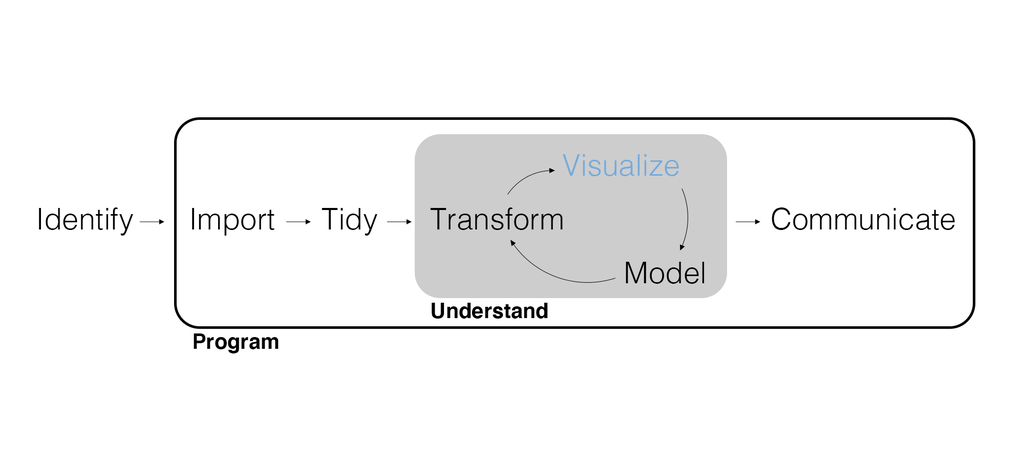

[figure not shown]

## Motivating Example

Imagine our client, Patagonia, has been happy with the results we’ve obtained from transforming the data (filtering, mutating, joining, slicing, etc.). Suppose that your results have been shared with the technical team, but that stakeholders are asking for a presentation on your results. What are some concise and effective ways that you could communicate data-based insights about Patagonia’s customer base?

## Discrete Data

Visualizations are a form of **summarizing data**. Summarizing data is initially all about discovery, the heart of **exploratory data analysis**.

- Computing **statistics** (i.e., numerical summaries).
- **Visualizing** data (i.e., graphical summaries).

How we summarize depends on whether the data is **discrete** or **continuous**.

- Discrete values are separate and distinct; numeric counts are discrete too.
- This lecture focuses on **categorical variables**, whose values identify groups.

```r
library(tidyverse)
```

Can you identify any *discrete* variables? What are their data types in R?

```r
customer_data <- read_csv("customer_data.csv", show_col_types = FALSE)
glimpse(customer_data)
```

```
## Rows: 10,531
## Columns: 14
## $ customer_id    <dbl> 1001, 1002, 1003, 1004, 1005, 1006, 1007, 1008, 1009, 1…
## $ birth_year     <dbl> 1971, 1970, 1988, 1984, 1987, 1994, 1968, 1994, 1958, 1…
## $ gender         <chr> "Female", "Female", "Male", "Other", "Male", "Male", "M…
## $ income         <dbl> 73000, 31000, 35000, 64000, 58000, 164000, 39000, 69000…
## $ credit         <dbl> 742.0827, 749.3514, 542.2399, 573.9358, 644.2439, 553.6…
## $ married        <chr> "No", "Yes", "No", "Yes", "No", "Yes", "No", "No", "No"…
## $ college_degree <chr> "No", "No", "No", "Yes", "Yes", "Yes", "No", "No", "No"…
## $ region         <chr> "South", "West", "South", "Midwest", "West", "Midwest",…
## $ state          <chr> "DC", "WA", "AR", "MN", "HI", "MN", "MN", "KY", "NM", "…
## $ review_id      <dbl> 933551, NA, NA, NA, 501318, 109125, NA, 1959683, NA, 19…
## $ star_rating    <dbl> 4, NA, NA, NA, 5, 2, NA, 5, NA, 5, NA, 5, NA, NA, NA, N…
## $ review_time    <chr> "06 11, 2015", NA, NA, NA, "03 25, 2008", "06 7, 2013",…
## $ review_title   <chr> "Four Stars", NA, NA, NA, "Great Product!!", "Not at al…
## $ review_text    <chr> "everything's fine", NA, NA, NA, "I looked all over the…
```

## A Word About Data Types

Data **types** in R — as in all programming languages — are more than simple labels. They serve as essential instructions that tell the computer how to interpret and manipulate the values we provide. Some common ones include:

| **Data Type** | **Abbreviation** | **Description** |
| --- | --- | --- |
| `logical` | `lgl` | Boolean values: `TRUE`, `FALSE`, or `NA` |
| `integer` | `int` | Whole numbers (e.g. `1`, `42`) |
| `double` (numeric) | `dbl` | Decimal numbers (e.g. `3.14`, `2.0`) |
| `character` | `chr` | Text strings (e.g. `"hello"`, `"R"`) |
| `factor` | `fct` | Categorical data with fixed levels (e.g. `"Low"`, `"High"`) |

## Summarize Discrete Data

An important statistic for a discrete variable is a **count**.

```r
customer_data |>
  count(region)
```

```
## # A tibble: 4 × 2
##   region        n
##   <chr>     <int>
## 1 Midwest    1101
## 2 Northeast  3224
## 3 South      1111
## 4 West       5095
```

How would I get a count by both `region` and `college_degree` (i.e., a **cross-tab**)?

```r
customer_data |>
  count(region, college_degree)
```

```
## # A tibble: 8 × 3
##   region    college_degree     n
##   <chr>     <chr>          <int>
## 1 Midwest   No               229
## 2 Midwest   Yes              872
## 3 Northeast No               640
## 4 Northeast Yes             2584
## 5 South     No               891
## 6 South     Yes              220
## 7 West      No               989
## 8 West      Yes             4106
```

## Your Turn!

Write code that first filters the data to only unmarried customers, then counts the customers in each region (you will need to use code we learned in the last lecture to do this!)

**Expected output:**

```
## # A tibble: 4 × 2
##   region        n
##   <chr>     <int>
## 1 Midwest     578
## 2 Northeast  1791
## 3 South       587
## 4 West       2783
```

## Here’s The Solution

```r
customer_data |>
  filter(married == 'No') |>
  count(region)
```

## Visualize Data

{ggplot2} provides a consistent **grammar of graphics** built with **layers**.

1. Data – Data to visualize.
2. Aesthetics – Or “aes,” mapping graphical elements to data.
3. Geometry – Or “geom,” the kind of graph representing the data.
4. Facets, Labels, Scales, etc.

[figure not shown]

## Visualize Discrete Data

Let’s plot our first summary (note how `+` is different from `|>`).

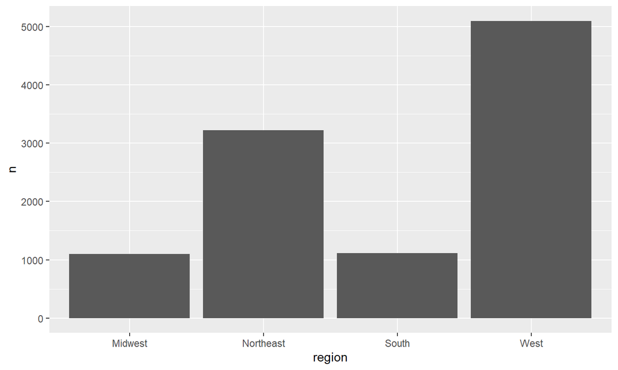

```r
customer_data |>
  count(region) |>
  ggplot(aes(x = region, y = n)) +
  geom_col()
```

The aesthetic `fill = college_degree` colors the categories. By default, `geom_col()` stacks their counts.

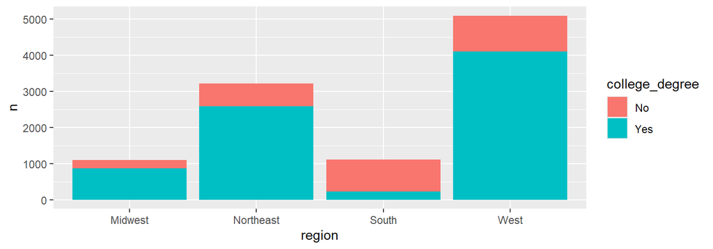

```r
customer_data |>
  count(region, college_degree) |>
  ggplot(aes(x = region, y = n, fill = college_degree)) +
  geom_col()
```

Set `position = "fill"` in `geom_col()` to show proportions: each region’s full bar represents 100% of its customers.

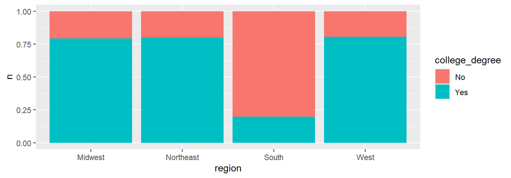

```r
customer_data |>
  count(region, college_degree) |>
  ggplot(aes(x = region, y = n, fill = college_degree)) +
  geom_col(position = "fill")
```

## Facets

Facets allow us to visualize by another discrete variable. For example, we can examine whether the relationship between `college_degree` and `region` is different depending on `gender`.

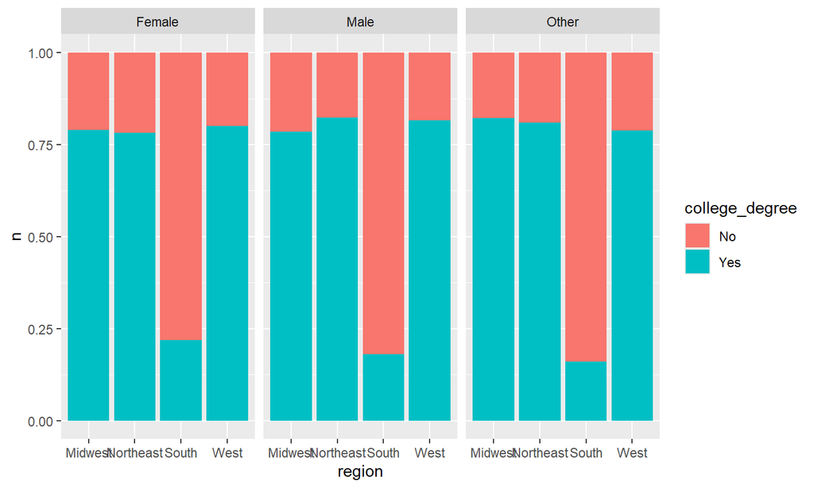

```r
customer_data |>
  count(region, college_degree, gender) |>
  ggplot(aes(x = region, y = n, fill = college_degree)) +
  geom_col(position = "fill") +
  facet_wrap(~ gender)
```

## Your Turn!

### Audience Size or Concentration?

Patagonia is considering a campaign for customers without college degrees. Management wants to understand how this audience differs across regions and marital-status groups.

Create a faceted bar chart showing the **proportions of college-degree categories within each region**, with separate panels for marital status. Each full bar should represent 100% of the customers in that region and panel.

Which region has the greatest concentration of customers without degrees? Would a chart of raw counts answer the same business question?

## Here’s What Your Output Should Be

Panels show `married = No` and `married = Yes`. Each bar has its own region-and-marital-status denominator.

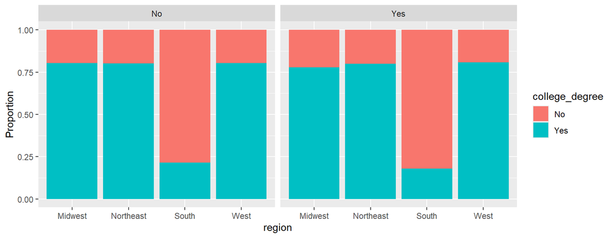

## Here’s The Solution

### Faceted Proportions

```r
customer_data |>
  count(region, college_degree, married) |>
  ggplot(aes(x = region, y = n, fill = college_degree)) +
  geom_col(position = "fill") +
  facet_wrap(~ married) +
  labs(y = "Proportion")
```

The South has the largest **share** without degrees in both panels. The `labs()` line names the vertical axis; we’ll explore labels next.

## What Changes When We Use Counts?

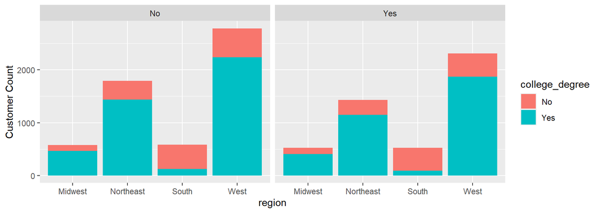

The West has the largest **number** without degrees in both panels; the South has the largest **share**. Counts describe audience size; proportions describe concentration. Which matters for the campaign decision?

## Labels and Scales

Our proportion plots show shares rather than counts on the y-axis. Let’s improve the labels on our earlier region-and-gender plot.

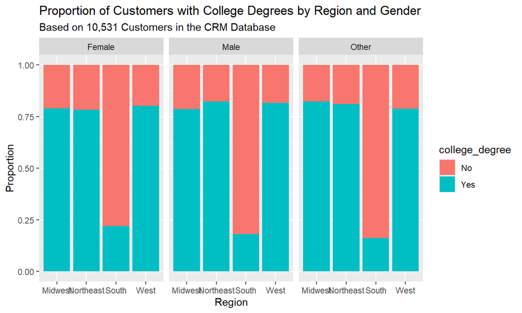

```r
customer_data |>
  count(region, college_degree, gender) |>
  ggplot(aes(x = region, y = n, fill = college_degree)) +
  geom_col(position = "fill") +
  facet_wrap(~ gender) +
  labs(
    title = "Proportion of Customers with College Degrees by Region and Gender",
    subtitle = "Based on 10,531 Customers in the CRM Database",
    x = "Region",
    y = "Proportion"
  )
```

What about the legend? And these *colors*?

Append this scale to the preceding plot with `+`. The complete pipeline is in your starter code.

```r
scale_fill_manual(
  name = "College Degree",
  values = c("cornflowerblue", "navy")
)
```

## What Else Should We Change? Are All Plot Aspects Legible?

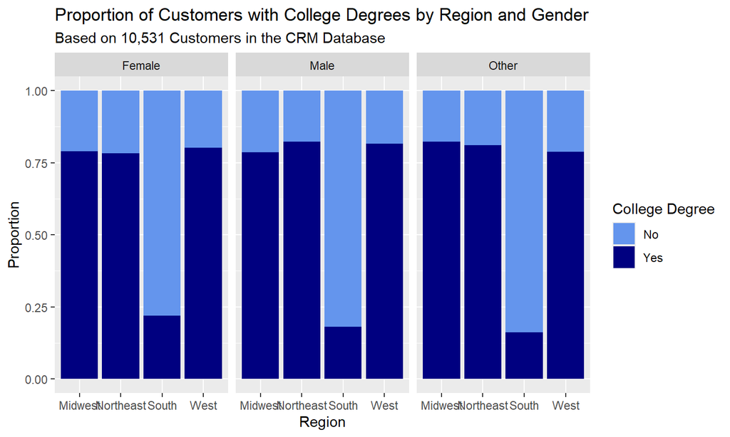

## Let’s Rotate the X-axis Labels

Append this theme adjustment to the labeled, recolored plot with `+`.

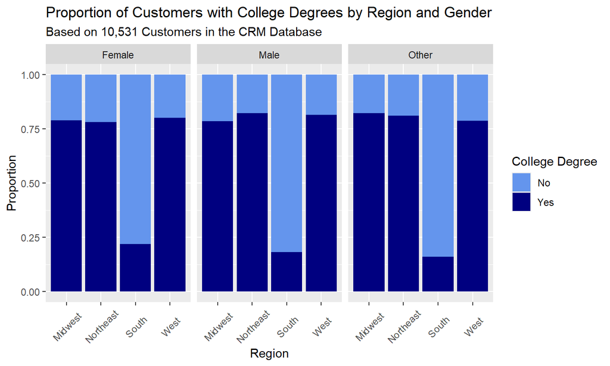

```r
theme(axis.text.x = element_text(angle = 45, vjust=0.5))
```

## Your Turn!

Look at the ggplot below (also found in your starter code). Figure out what summary it is displaying, and then add polished labels and colors to create a publication-ready graph.

```r
customer_data |>
  filter(region == "Northeast") |>
  count(state, married) |>
  ggplot(aes(x = state, y = n, fill = married)) +
  geom_col(position = "fill")
```

## Possible Solution

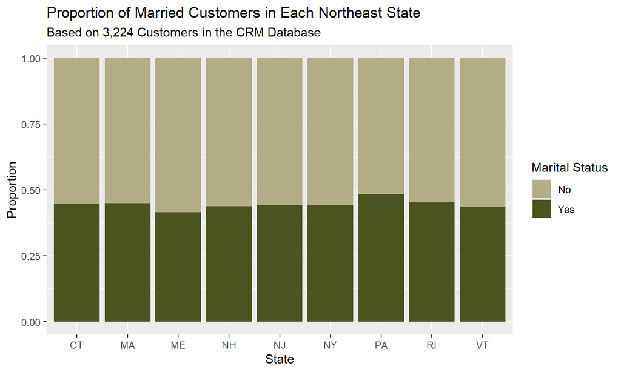

```r
customer_data |>
  filter(region == "Northeast") |>
  count(state, married) |>
  ggplot(aes(x = state, y = n, fill = married)) +
  geom_col(position = "fill") +
  labs(
    title = "Proportion of Married Customers in Each Northeast State",
    subtitle = "Based on 3,224 Customers in the CRM Database",
    x = "State",
    y = "Proportion"
  ) +
  scale_fill_manual(
    name = "Marital Status",
    values = c("#B2AC88", "#4b5320")
  )
```

## Text Data

Free-form text is **unstructured**. Tokenization turns it into word categories that we can count and visualize.

- Authors can express themselves freely.
- The same idea can be expressed in many ways.

What sort of structure might we impose on text data so we can visualize it?

## Tokenize Text Data

We can use `unnest_tokens()` to **tokenize** the text (i.e., split it into individual words or tokens).

```r
library(tidytext)

review_data <- customer_data |>
  select(customer_id, review_text) |>
  unnest_tokens(word, review_text)

review_data
```

```
## # A tibble: 165,510 × 2
##    customer_id word
##          <dbl> <chr>
##  1        1001 everything's
##  2        1001 fine
##  3        1002 <NA>
##  4        1003 <NA>
##  5        1004 <NA>
##  6        1005 i
##  7        1005 looked
##  8        1005 all
##  9        1005 over
## 10        1005 the
## # ℹ 165,500 more rows
```

## Summarize Text Data

With the text data tokenized, we can compute counts just like other discrete data.

```r
review_data |>
  count(word) |>
  arrange(desc(n))
```

```
## # A tibble: 10,178 × 2
##    word      n
##    <chr> <int>
##  1 the    7512
##  2 <NA>   7373
##  3 and    4633
##  4 i      4486
##  5 a      4176
##  6 to     3949
##  7 it     3581
##  8 for    2531
##  9 is     2419
## 10 of     2106
## # ℹ 10,168 more rows
```

## Drop Missing Data

**Missing values** are (and should be) encoded as `NA`.

```r
review_data <- review_data |>
  drop_na(word)

review_data
```

```
## # A tibble: 158,137 × 2
##    customer_id word
##          <dbl> <chr>
##  1        1001 everything's
##  2        1001 fine
##  3        1005 i
##  4        1005 looked
##  5        1005 all
##  6        1005 over
##  7        1005 the
##  8        1005 internet
##  9        1005 to
## 10        1005 find
## # ℹ 158,127 more rows
```

## Remove Stop Words

Commonly used words aren’t very informative and are referred to as **stop words**.

```r
stop_words
```

```
## # A tibble: 1,149 × 2
##    word        lexicon
##    <chr>       <chr>
##  1 a           SMART
##  2 a's         SMART
##  3 able        SMART
##  4 about       SMART
##  5 above       SMART
##  6 according   SMART
##  7 accordingly SMART
##  8 across      SMART
##  9 actually    SMART
## 10 after       SMART
## # ℹ 1,139 more rows
```

This is just a data frame, and we know how to join data frames!

An **anti join** returns rows that *don’t* have matching IDs, keeping only the columns from the “left” data frame. (Think of it as the opposite of an inner join.)

```r
review_data <- review_data |>
  anti_join(stop_words, join_by(word))

review_data |>
  count(word) |>
  arrange(desc(n))
```

```
## # A tibble: 9,552 × 2
##    word        n
##    <chr>   <int>
##  1 fit       403
##  2 product   378
##  3 easy      338
##  4 quality   330
##  5 nice      324
##  6 bag       287
##  7 price     281
##  8 time      278
##  9 love      264
## 10 size      247
## # ℹ 9,542 more rows
```

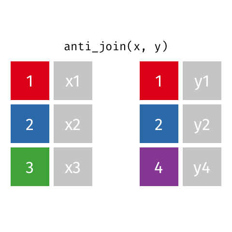

## Visualize Word Counts

```r
review_data |>
  count(word) |>
  arrange(desc(n)) |>
  ggplot(aes(x = word, y = n)) +
  geom_col()
```

What can we do to make this plot readable?

[figure not shown]

## Factors

### Choose the Category Order

Alphabetical order is not always the order we want.

```r
sizes <- c("small", "medium", "large")
sort(sizes)
```

```
## [1] "large"  "medium" "small"
```

## Factors

### Set the Size Order

Specify the category sequence with a factor:

```r
sizes <- factor(sizes, levels = c("small", "medium", "large"))
sort(sizes)
```

```
## [1] small  medium large
## Levels: small medium large
```

Creating the factor sets its category order; it does not rearrange observations. Here, `sort()` uses that order to display the values.

## Factors

### Order Students by Height

These three students are hypothetical. We want the names ordered by height, rather than alphabetically.

```r
students <- tibble(
  student = c("Alex", "Bailey", "Casey"),
  height_cm = c(178, 165, 190)
)
```

## Factors

### Use Height to Order the Names

Use height to set the name categories from shortest to tallest.

```r
students <- students |>
  mutate(student = fct_reorder(student, height_cm))

levels(students$student)
```

```
## [1] "Bailey" "Alex"   "Casey"
```

`fct_reorder()` sets the order to **Bailey, Alex, Casey**, from shortest to tallest. The rows stay in their original order.

## The Chart Uses the Factor Order

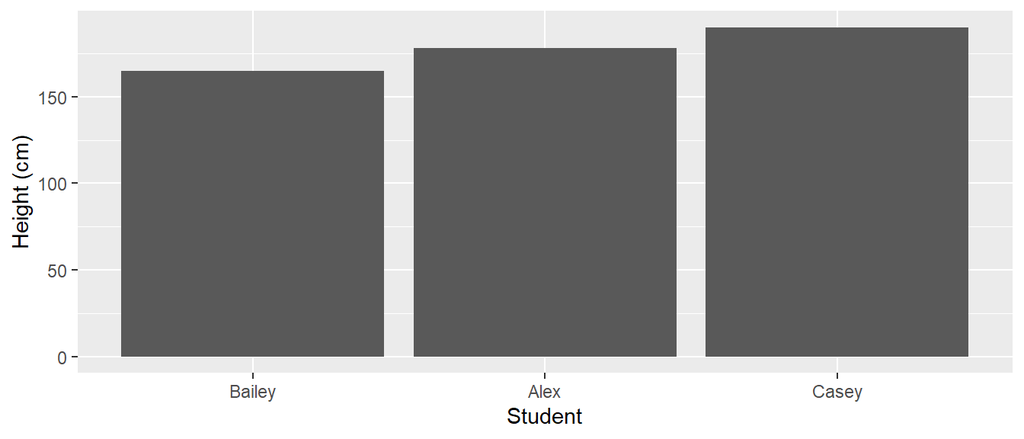

```r
students |>
  ggplot(aes(x = student, y = height_cm)) +
  geom_col() +
  labs(x = "Student", y = "Height (cm)")
```

Now apply the same idea to words: order the word categories by their counts.

## Apply Factor Order to Word Counts

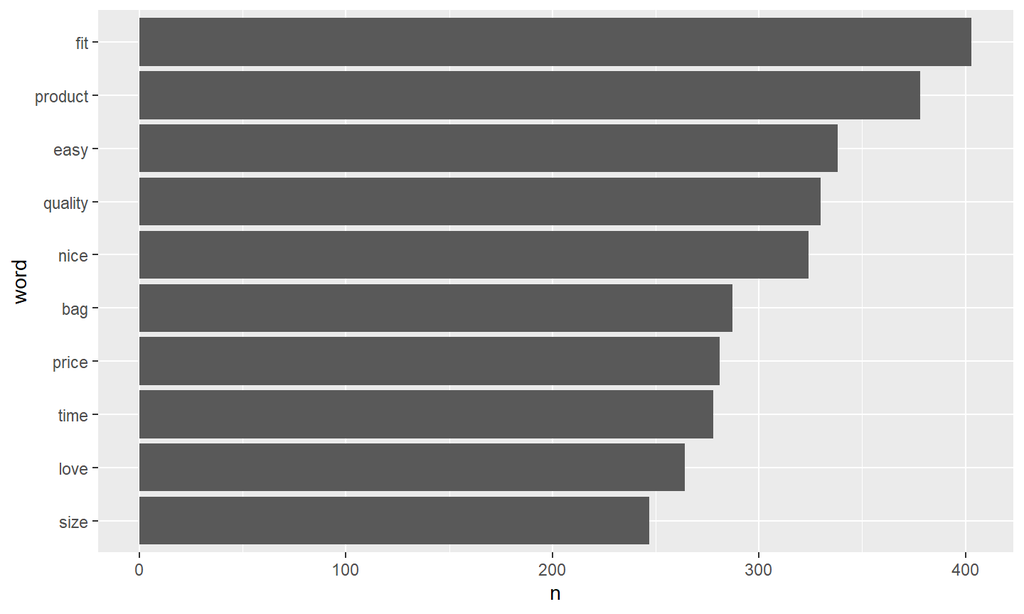

```r
review_data |>
  count(word) |>
  arrange(desc(n)) |>
  slice(1:10) |>
  mutate(word = fct_reorder(word, n)) |>
  ggplot(aes(x = n, y = word)) +
  geom_col()
```

## Factors

### What a Factor Stores

Unlike a character variable, a **factor** stores a defined sequence of categories.

- Integer codes represent categories internally; `levels` stores their names as character strings.
- The level sequence controls plotting order. `fct_reorder()` changes that sequence using another variable.

## Live Coding

Going back to our prompt from the beginning, imagine Patagonia management is interested in a breakdown of the type of customers, and their preferences, in the `South` region. What type of visualization could we do to accomplish this?

## Wrapping Up

*Summary*

- Computed counts, including tokenizing and counting text.
- Practiced the basics of plotting with {ggplot2}.

*Next Time*

- Summarizing continuous data with {dplyr}.
- Visualizing continuous data with {ggplot2}.

*Supplementary Material*

- *R for Data Science (2e)*: [1 Data visualization](https://r4ds.hadley.nz/data-visualize.html), [9 Layers](https://r4ds.hadley.nz/layers.html), and [16 Factors](https://r4ds.hadley.nz/factors.html).
- Optional background: [18 Missing values](https://r4ds.hadley.nz/missing-values.html).

*Artwork by @allison_horst*